# Task_2

Galikeeva

11 04 2020

1. Прочитать данные

```r
library(xts)
rates <- read.csv("./rates_1.csv",header = TRUE )
head(rates)
```

```
##       Date X1.Mo X2.Mo X3.Mo X6.Mo X1.Yr X2.Yr X3.Yr X5.Yr X7.Yr X10.Yr X20.Yr
## 1 1/2/2020  1.53  1.55  1.54  1.57  1.56  1.58  1.59  1.67  1.79   1.88   2.19
## 2 1/3/2020  1.52  1.55  1.52  1.55  1.55  1.53  1.54  1.59  1.71   1.80   2.11
## 3 1/6/2020  1.54  1.54  1.56  1.56  1.54  1.54  1.56  1.61  1.72   1.81   2.13
## 4 1/7/2020  1.52  1.53  1.54  1.56  1.53  1.54  1.55  1.62  1.74   1.83   2.16
## 5 1/8/2020  1.50  1.53  1.54  1.56  1.55  1.58  1.61  1.67  1.78   1.87   2.21
## 6 1/9/2020  1.53  1.55  1.54  1.56  1.54  1.58  1.59  1.65  1.77   1.85   2.17
##   X30.Yr
## 1   2.33
## 2   2.26
## 3   2.28
## 4   2.31
## 5   2.35
## 6   2.38
```

Взяты данные за 2020 год с сайта https://www.treasury.gov/resource-center/data-chart-center/interest-rates/Pages/TextView.aspx?data=yieldYear&year=2020

2. Вывести график доходностей

```r
(ndays  <-  dim(rates)[1])
```

```
## [1] 66
```

```r
(ncol  <-  dim(rates)[2])
```

```
## [1] 13
```

```r
tr_dates <- as.Date(rates[,1],"%m/%d/%Y")
rates.xts <- as.xts(rates[2:ncol], order.by = tr_dates)
head(rates.xts)
```

```
##            X1.Mo X2.Mo X3.Mo X6.Mo X1.Yr X2.Yr X3.Yr X5.Yr X7.Yr X10.Yr X20.Yr
## 2020-01-02  1.53  1.55  1.54  1.57  1.56  1.58  1.59  1.67  1.79   1.88   2.19
## 2020-01-03  1.52  1.55  1.52  1.55  1.55  1.53  1.54  1.59  1.71   1.80   2.11
## 2020-01-06  1.54  1.54  1.56  1.56  1.54  1.54  1.56  1.61  1.72   1.81   2.13
## 2020-01-07  1.52  1.53  1.54  1.56  1.53  1.54  1.55  1.62  1.74   1.83   2.16
## 2020-01-08  1.50  1.53  1.54  1.56  1.55  1.58  1.61  1.67  1.78   1.87   2.21
## 2020-01-09  1.53  1.55  1.54  1.56  1.54  1.58  1.59  1.65  1.77   1.85   2.17
##            X30.Yr
## 2020-01-02   2.33
## 2020-01-03   2.26
## 2020-01-06   2.28
## 2020-01-07   2.31
## 2020-01-08   2.35
## 2020-01-09   2.38
```

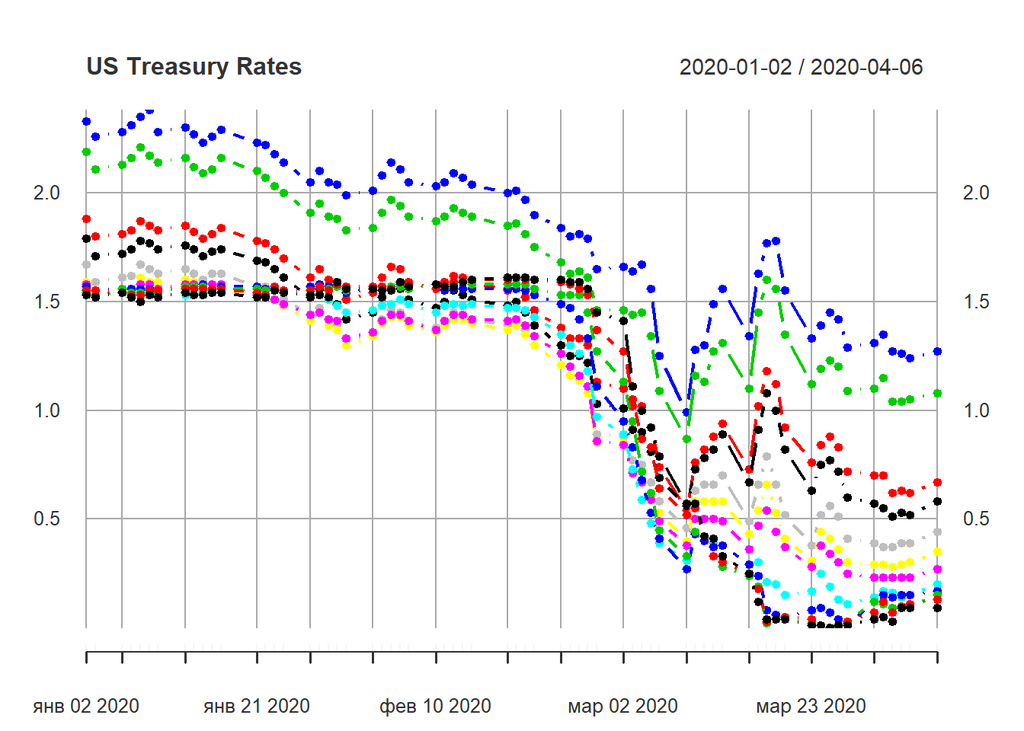

```r
plot(rates.xts,type = 'b',pch =20,main = "US Treasury Rates")
```

3. Провести к доходностям метод главных компонент

```r
pca <- prcomp(rates.xts, scale = FALSE)
summary(pca)
```

```
## Importance of components:
##                           PC1    PC2     PC3     PC4     PC5     PC6     PC7
## Standard deviation     1.8260 0.3520 0.09084 0.06040 0.02165 0.02071 0.01658
## Proportion of Variance 0.9604 0.0357 0.00238 0.00105 0.00014 0.00012 0.00008
## Cumulative Proportion  0.9604 0.9961 0.99849 0.99954 0.99967 0.99980 0.99988
##                            PC8     PC9     PC10     PC11    PC12
## Standard deviation     0.01173 0.01014 0.009073 0.008163 0.00663
## Proportion of Variance 0.00004 0.00003 0.000020 0.000020 0.00001
## Cumulative Proportion  0.99991 0.99994 0.999970 0.999990 1.00000
```

4. Построить график стандартных отклоненией

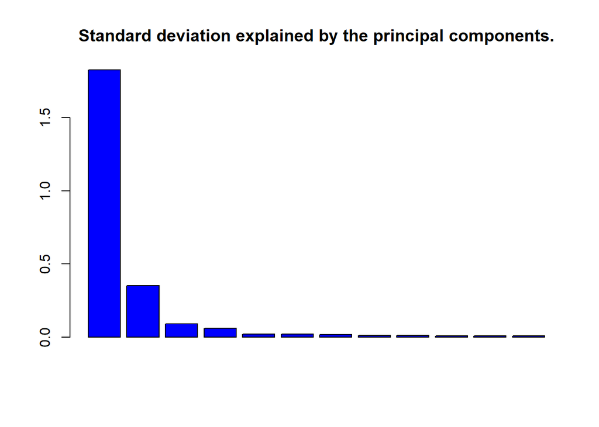

```r
mp <- barplot(pca$sdev,main = "Standard deviation explained by the principal components.", col = "blue")
```

5. Построить график важности каждой главной компоненты

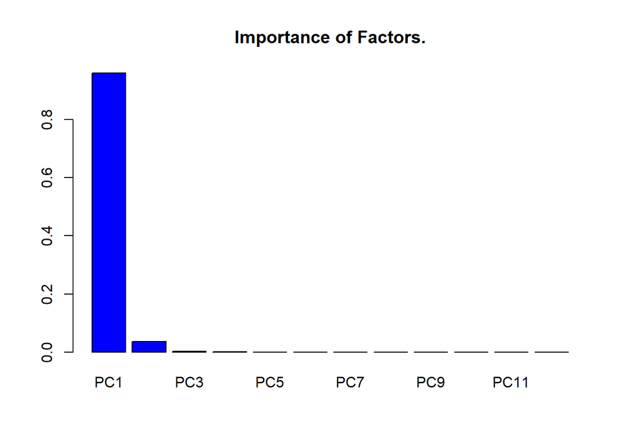

```r
ss <- summary(pca)
mp <- barplot(ss$importance[2,],main = "Importance of Factors.", col = "blue")
```

6. Построить график накопленной меры информативности
7. Определить сколько главных факторов объясняют более 95% дисперсии

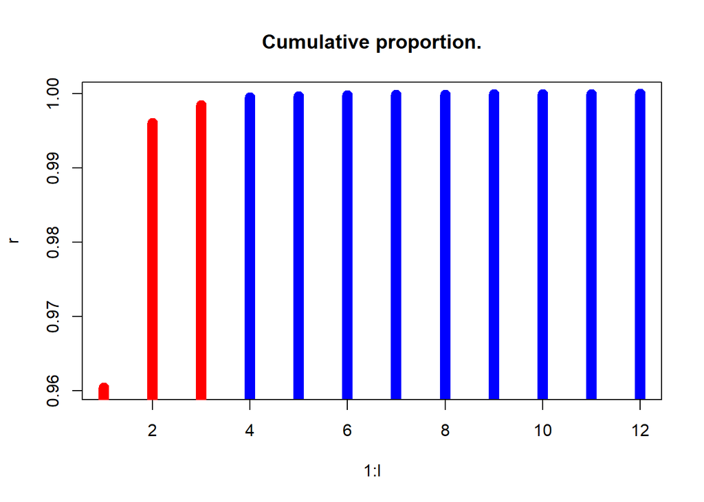

```r
his <- ss$importance[3,]
l <- length(his)
his[4:l]<- NA
r <- as.matrix(cbind(ss$importance[3,],his))
mp <- matplot(1:l,r,type = 'h',lty = 1, lwd = 10,main = "Cumulative proportion.", col = c("blue",'red')) # default
abline(h = 0.95,col = 'black')
```

8. Получить главные факторы Shift,Twist,ButterFly

```r
scores <- function(ldata,pca,number)
{
  cdata <- ldata
  m <- dim(ldata)[2]
  for (i in 1:m)
    cdata[,i] <- ldata[,i] - pca$center[i]
  loads <- pca$rotation[,1:number]
  cdata <- as.matrix(cdata)
  f <- cdata %*% loads
  return (f)
}

number <- 3
fscores <- scores(rates.xts,ss,number)
(shift <- fscores[,1])
```

```
##  2020-01-02  2020-01-03  2020-01-06  2020-01-07  2020-01-08  2020-01-09
## -1.77452232 -1.63956114 -1.68328454 -1.68331748 -1.75899031 -1.75366316
##  2020-01-10  2020-01-13  2020-01-14  2020-01-15  2020-01-16  2020-01-17
## -1.69582865 -1.75452308 -1.71795295 -1.67591252 -1.70282368 -1.73621429
##  2020-01-21  2020-01-22  2020-01-23  2020-01-24  2020-01-27  2020-01-28
## -1.62943112 -1.60676141 -1.58832054 -1.51484572 -1.38807235 -1.46292313
##  2020-01-29  2020-01-30  2020-01-31  2020-02-03  2020-02-04  2020-02-05
## -1.35445294 -1.35469944 -1.20473884 -1.26847128 -1.38259230 -1.45560159
##  2020-02-06  2020-02-07  2020-02-10  2020-02-11  2020-02-12  2020-02-13
## -1.47109664 -1.37085699 -1.32115513 -1.35937508 -1.43650909 -1.42397231
##  2020-02-14  2020-02-18  2020-02-19  2020-02-20  2020-02-21  2020-02-24
## -1.39809773 -1.34483286 -1.37239213 -1.29435121 -1.16864406 -0.98033912
##  2020-02-25  2020-02-26  2020-02-27  2020-02-28  2020-03-02  2020-03-03
## -0.86634558 -0.81105142 -0.64249236 -0.01058576  0.18830380  0.67703654
##  2020-03-04  2020-03-05  2020-03-06  2020-03-09  2020-03-10  2020-03-11
##  0.98047974  1.29510175  1.79128385  2.29481980  1.82073767  1.91591321
##  2020-03-12  2020-03-13  2020-03-16  2020-03-17  2020-03-18  2020-03-19
##  1.90881457  1.90629075  2.34021997  2.09037314  2.09945628  2.23301654
##  2020-03-20  2020-03-23  2020-03-24  2020-03-25  2020-03-26  2020-03-27
##  2.50688183  2.77156092  2.58637452  2.59930977  2.69430287  2.84552416
##  2020-03-30  2020-03-31  2020-04-01  2020-04-02  2020-04-03  2020-04-06
##  2.76293349  2.71678295  2.82329377  2.78216814  2.77554099  2.65308120
```

```r
(twist <- fscores[,2])
```

```
##    2020-01-02    2020-01-03    2020-01-06    2020-01-07    2020-01-08
##  0.4374216161  0.3090296864  0.3226583827  0.3760106860  0.4708294673
##    2020-01-09    2020-01-10    2020-01-13    2020-01-14    2020-01-15
##  0.4290803121  0.3644064768  0.3776813436  0.3334041091  0.2712335714
##    2020-01-16    2020-01-17    2020-01-21    2020-01-22    2020-01-23
##  0.3202954412  0.3542589399  0.2645463489  0.2493810426  0.1641802688
##    2020-01-24    2020-01-27    2020-01-28    2020-01-29    2020-01-30
##  0.1107871150 -0.0507073192  0.0096110798 -0.0757735975 -0.1519066584
##    2020-01-31    2020-02-03    2020-02-04    2020-02-05    2020-02-06
## -0.2428979120 -0.2030100783 -0.0701201713  0.0284930346 -0.0323189487
##    2020-02-07    2020-02-10    2020-02-11    2020-02-12    2020-02-13
## -0.1121372098 -0.1775580566 -0.1168581552 -0.0487810580 -0.0887989692
##    2020-02-14    2020-02-18    2020-02-19    2020-02-20    2020-02-21
## -0.1340972704 -0.2038560222 -0.1808109872 -0.2580325008 -0.3630718819
##    2020-02-24    2020-02-25    2020-02-26    2020-02-27    2020-02-28
## -0.4936214493 -0.5753366344 -0.5650556965 -0.5651070187 -0.7193185983
##    2020-03-02    2020-03-03    2020-03-04    2020-03-05    2020-03-06
## -0.6177162432 -0.4774325894 -0.2805667803 -0.3618079187 -0.5207439558
##    2020-03-09    2020-03-10    2020-03-11    2020-03-12    2020-03-13
## -0.6755886839 -0.3180355239 -0.1558843718  0.0633227195  0.2113412590
##    2020-03-16    2020-03-17    2020-03-18    2020-03-19    2020-03-20
## -0.0997260374  0.4842938806  0.9227503137  0.7933126290  0.4409822125
##    2020-03-23    2020-03-24    2020-03-25    2020-03-26    2020-03-27
##  0.1189691443  0.3109765065  0.3817290072  0.2995812984  0.0842578089
##    2020-03-30    2020-03-31    2020-04-01    2020-04-02    2020-04-03
##  0.0007526103 -0.0031885003 -0.0799255577 -0.1047723492 -0.1198032965
##    2020-04-06
## -0.0612103104
```

```r
(butterfly <- fscores[,3])
```

```
##    2020-01-02    2020-01-03    2020-01-06    2020-01-07    2020-01-08
##  0.0362522272  0.0101590703  0.0227712853  0.0405505178  0.0324251784
##    2020-01-09    2020-01-10    2020-01-13    2020-01-14    2020-01-15
##  0.0597772822  0.0178875593  0.0294424157  0.0005092952 -0.0230282883
##    2020-01-16    2020-01-17    2020-01-21    2020-01-22    2020-01-23
## -0.0002572000  0.0217288258 -0.0113645146 -0.0264506831 -0.0255871405
##    2020-01-24    2020-01-27    2020-01-28    2020-01-29    2020-01-30
## -0.0469631647 -0.0954702957 -0.0714666687 -0.0884213108 -0.0361298072
##    2020-01-31    2020-02-03    2020-02-04    2020-02-05    2020-02-06
## -0.0340278214 -0.0492715336 -0.0379789409 -0.0121680988 -0.0178993956
##    2020-02-07    2020-02-10    2020-02-11    2020-02-12    2020-02-13
## -0.0462783779 -0.0301252523 -0.0345024863 -0.0260880108 -0.0254615878
##    2020-02-14    2020-02-18    2020-02-19    2020-02-20    2020-02-21
## -0.0332263209 -0.0415367048 -0.0388365272 -0.0517238958 -0.0611284774
##    2020-02-24    2020-02-25    2020-02-26    2020-02-27    2020-02-28
## -0.0246000147 -0.0135019797  0.0390771630  0.0935338090  0.1798178047
##    2020-03-02    2020-03-03    2020-03-04    2020-03-05    2020-03-06
##  0.2432475740  0.2018506152  0.2673059704  0.2742939700  0.0822415237
##    2020-03-09    2020-03-10    2020-03-11    2020-03-12    2020-03-13
## -0.0990006200 -0.0568512036 -0.1350622521 -0.0140600859 -0.0115615738
##    2020-03-16    2020-03-17    2020-03-18    2020-03-19    2020-03-20
## -0.0904033457  0.0421701147  0.1467912577  0.2036515633  0.1013187251
##    2020-03-23    2020-03-24    2020-03-25    2020-03-26    2020-03-27
## -0.0601798619 -0.1096604370 -0.0334999690  0.0062562709 -0.0425053433
##    2020-03-30    2020-03-31    2020-04-01    2020-04-02    2020-04-03
## -0.0575492874 -0.0311742771 -0.1181371431 -0.0817506217 -0.0926710530
##    2020-04-06
## -0.1154984449
```

9. Построить графики нагрузок shift,twist,butterfly.

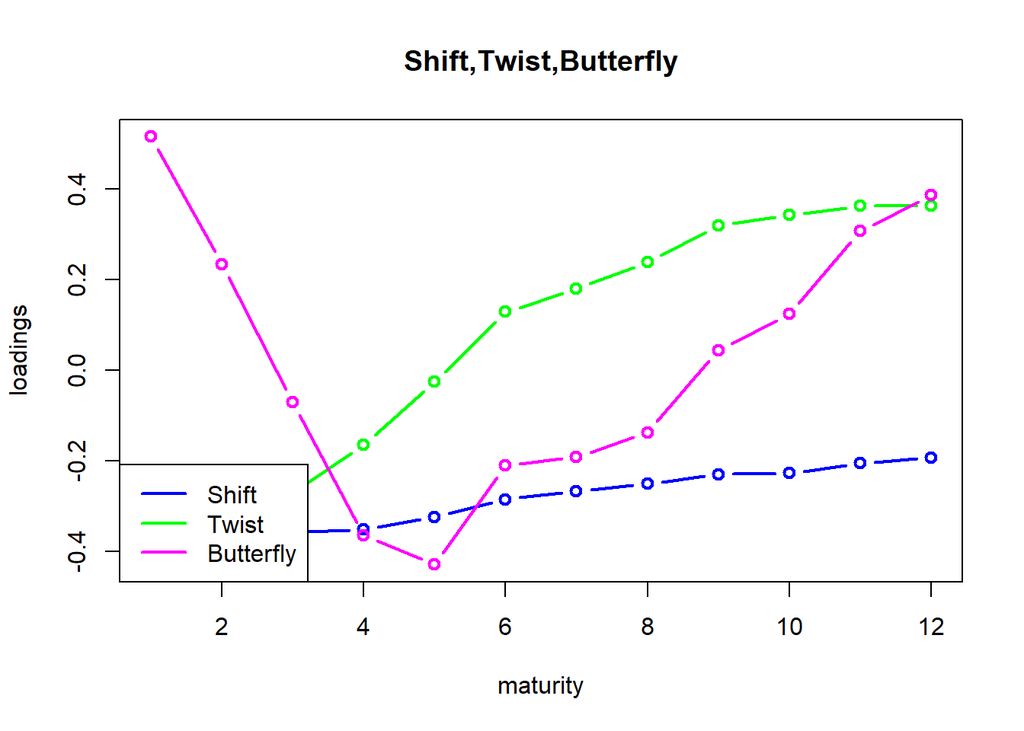

```r
matplot(cbind(ss$rotation[,1],ss$rotation[,2],ss$rotation[,3]),type = 'b',pch=21,lwd = 2,
        col = c("blue","green","magenta"),main= "Shift,Twist,Butterfly",ylab = "loadings",xlab="maturity",lty=1 )
legend("bottomleft",c("Shift","Twist","Butterfly"),lty=c(1,1,1),lwd = 2,col = c("blue","green","magenta"))
```

10. Построить графики факторов shift,twist,butterfly.

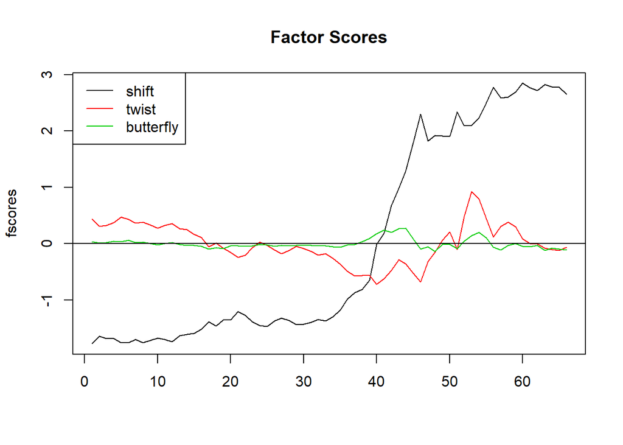

```r
matplot(fscores,type = 'l',lty = 1, col = 1:number,main = 'Factor Scores')
legend('topleft',c('shift','twist','butterfly'),col = 1:number,lty = 1)
abline(h=0)
```

11. Восстановить для последнего дня доходности по факторам и сравнить оригинальные и восстановленные доходности последнего дня.

```r
restoreData<- function(fscores,loadings,center)
{
  npca <- dim(fscores)[2]
  myeigen <- t(loadings[,1:npca])
  rest <- fscores %*%myeigen
  m <- length(center)
  if (m == dim(rest)[2])
  {
    for (i in 1:m)
      rest[,i] <- rest[,i]+center[i]
  }
  return(rest)
}

lastdate <- rates[ndays,1]
rest <- restoreData(fscores,ss$rotation,ss$center)
ndays <- dim(fscores)[1]
head(rest)
```

```
##               X1.Mo    X2.Mo    X3.Mo    X6.Mo    X1.Yr    X2.Yr    X3.Yr
## 2020-01-02 1.520813 1.543148 1.556718 1.576853 1.561612 1.584085 1.589856
## 2020-01-03 1.515043 1.536036 1.545071 1.560198 1.532351 1.534672 1.535910
## 2020-01-06 1.530973 1.549443 1.556107 1.568686 1.540777 1.546215 1.547584
## 2020-01-07 1.517390 1.534262 1.540430 1.553445 1.531782 1.549336 1.553735
## 2020-01-08 1.499187 1.524677 1.542413 1.567303 1.557343 1.584757 1.592429
## 2020-01-09 1.529196 1.544298 1.549844 1.562361 1.544984 1.572130 1.578296
##               X5.Yr    X7.Yr   X10.Yr   X20.Yr   X30.Yr
## 2020-01-02 1.644088 1.781496 1.877959 2.194077 2.349044
## 2020-01-03 1.583183 1.708478 1.800187 2.111925 2.266361
## 2020-01-06 1.595674 1.723406 1.816341 2.129691 2.284615
## 2020-01-07 1.605970 1.741198 1.836781 2.154463 2.310828
## 2020-01-08 1.648685 1.788408 1.885372 2.201812 2.356677
## 2020-01-09 1.633639 1.775092 1.873282 2.193994 2.351075
```

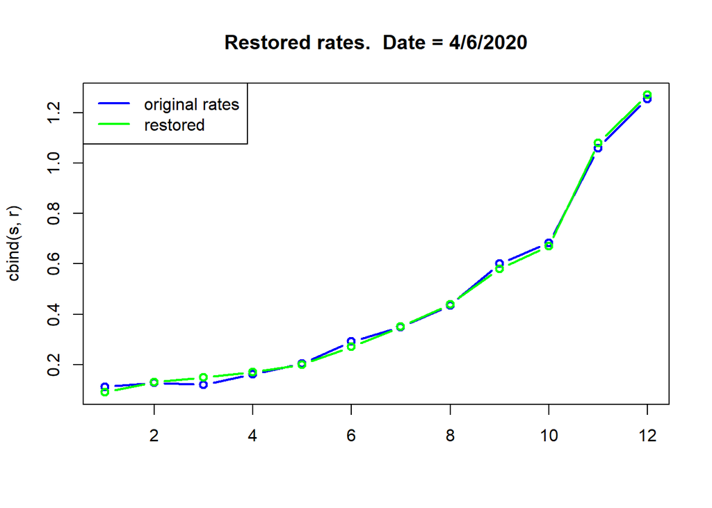

```r
r <- unlist(rates.xts[ndays,])
r <- as.matrix(r,ncol = 1)
r <- t(r)
s <- as.matrix(rest[ndays,],ncol = 1)
title <- paste('Restored rates.',' Date =',lastdate)
matplot(cbind(s,r),type ='b',pch=21,lwd = 2,main = title,col = c('blue','green'),lty = 1)
legend('topleft',c('original rates','restored'),lty=1,lwd=2,col=c('blue','green'))
```

12. Вычислить цену портфеля из облигаций в количестве (15,15,15,200,15,20,20,10,10,10,10,15) со сроками до окончания 1 Mo,2 Mo 3 Mo, 6 Mo, 1 Yr, 2 Yr ,3 Yr, 5 Yr, 7 Yr, 10 Yr, 20 Yr, 30 Yr, если каждая облигация имеет купон 3% и выплачивает купонный доход 2 раза в год для последнего дня заданного года по оригинальным рейтам и восстановленным по shift,twist,butterfly.

```r
library(FinAna)
par <- 100
m <- 2
coupon <- 0.03
tau <- c(1/12,1/6, 0.25, 0.5,1,2,3,5,7,10,20,30)
N <- c(15,15,15,200,15,20,20,10,10,10,10,15)
last_true <- 1:12
last_res <- 1:12

for (i in 1:12){
  last_true[i] <- rates.xts[ndays,i]
  last_res[i] <- rest[ndays,i]
}
P_or <- 0
P_res <- 0
for (i in 1:12){
  P_or <-  P_or + N[i] * bond.price(par,coupon,tau[i], last_true[i],m)
  P_res <-  P_res + N[i] * bond.price(par,coupon,tau[i],last_res[i],m)
}
P_or
```

```
## [1] 26959.5
```

```r
P_res
```

```
## [1] 26978.09
```

Получили близкие значения

13. Вычислить изменение фактора Twist между 3/17/20 и 3/18/20, когда ФРС США понизил ставку из-за проблем в экономике в связи с падением цен на нефть и коронавирусом.

```r
(twist[["2020-03-18"]] - twist[["2020-03-17"]])
```

```
## [1] 0.4384564
```